# Projectile Motion

Carmen Wright

October 29, 2017

3.3 Homework problem: When throwing an object, the distance achieved depends on its initial velocity, $v_0$, and the angle above the horizontal at which the object is thrown, $\theta$. The distance, $d$, in feet, that describes the range covered is given by the equation below, where $v_0$ is measured in feet per second.
$$\displaystyle d = \frac{(v_0)^2}{16} \sin \theta \cos \theta$$

Use an identity to express the formula so that it contains the sine function only. Recall the double-angle formula: $\sin 2\theta = 2 \sin \theta \cos \theta$. Now divide both sides by two and substitute:
$$\displaystyle d = \frac{(v_0)^2}{16} \sin \theta \cos \theta = \frac{(v_0)^2}{16} \frac{\sin 2\theta}{2} = \frac{(v_0)^2}{32} \sin 2\theta$$

## Why would this ever be useful?

#### 1. It makes it easier to determine what angles give us certain distances.

In other words, given a certain distance $d$, we could find an angle $\theta$ that gives us that distance. Solving for $\theta$ is easier to do in Formula 2 versus Formula 1.

First, what is the maximum distance? Since the range of the sine function is [-1,1], we know that $|\sin 2\theta|=1$. That means that the maximum distance $D_{max}$ is
$$D_{max} = \left| \frac{(v_0)^2}{32} \sin 2\theta \right| = \left| \frac{(v_0)^2}{32} \right| |\sin 2\theta | = \left| \frac{(v_0)^2}{32} \right| = \frac{(v_0)^2}{32}$$

What is the smallest angle, $\theta$ that produces a fraction, $a$, of the maximum distance, $d$, for a given initial speed, $v_0$? Let $d^*$ be the desired distance, $d^*=a D_{max}$. In other words, if we wanted half of the maximum distance, $d^*=\frac{1}{2}D_{max}$. We do not even need to know the maximum distance in order to find the smallest angle. We just set our formula equal to our desired distance and solve for $\theta$.
$$\frac{(v_0)^2}{32} \sin 2\theta = d^*$$
$$\frac{(v_0)^2}{32} \sin 2\theta = a D_{max}$$
$$\frac{(v_0)^2}{32} \sin 2\theta = a \frac{(v_0)^2}{32}$$
$$\sin 2\theta = a$$
$$2\theta = \arcsin(a)$$
$$\theta = \frac{\arcsin(a)}{2}$$
Remember that $a$ is the fraction of the distance.

Let’s say we want to know the smallest angle that gives us half of the maximum distance. Then
$$\theta = \frac{\arcsin(1/2)}{2}$$

```r
a <- 1/2
theta <- asin(a) / 2
theta
```

```
## [1] 0.2617994
```

#### 2. It could speed up computations.

Let’s define the two formulas as functions that receive the initial velocity and angle as inputs:

```r
projectile1 <- function(v0, theta)
{
  d <- (v0^2 / 16) * sin(theta) * cos(theta)
  return(d)
}

projectile2 <- function(v0, theta)
{
  d <- (v0^2 / 32) * sin(2*theta)
  return(d)
}
```

Suppose our initial velocity is 10 ft/sec, and we want to calculate the ranges for 25 acute angles between 1 and $\frac{\pi}{2} \approx 1.57$. Notice that from the plots that both formulas have the same output.

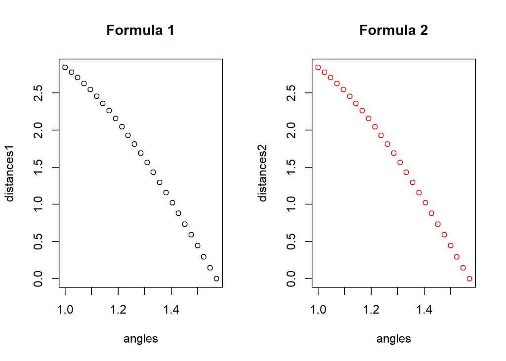

```r
init_vel <- 10
angles <- seq(1,pi/2,length.out = 25)

distances1 <- projectile1(init_vel, angles)
distances2 <- projectile2(init_vel, angles)

par(mfrow=c(1,2))
plot(angles,distances1,col=1,main="Formula 1")
plot(angles,distances2,col=2,main="Formula 2")
```

That was no problem. And it doesn’t seem to matter which formula we use. But we only ran it for 25 different inputs. What if we had much more?

```r
nvalues <- 100
velocities <- 1:nvalues
angles <- seq(1,pi/2,length.out = nvalues)
inputs <- expand.grid(velocities,angles)
N <- nrow(inputs)
print(paste("Number of calculations:",N))
```

```
## [1] "Number of calculations: 10000"
```

```r
dist1 <- numeric(N)
dist2 <- numeric(N)
```

Let’s time the first formula:

```r
library(tictoc)

tic("Formula 1")
for (i in 1:N)
{
  dist1[i] <- projectile1(inputs[i,1],inputs[i,2])
}
toc()
```

```
## Formula 1: 0.3 sec elapsed
```

Now the second formula:

```r
tic("Formula 2")
for (i in 1:N)
{
  dist2[i] <- projectile2(inputs[i,1],inputs[i,2])
}
toc()
```

```
## Formula 2: 0.35 sec elapsed
```

10000 may be a lot of calculations, but not enough to make a difference. Let’s try it with more calculations.

```r
nvalues <- 500
velocities <- 1:nvalues
angles <- seq(1,pi/2,length.out = nvalues)
inputs <- expand.grid(velocities,angles)
N <- nrow(inputs)
print(paste("Number of calculations:",N))
```

```
## [1] "Number of calculations: 250000"
```

```r
dist1 <- numeric(N)
dist2 <- numeric(N)
```

Let’s time the first formula:

```r
library(tictoc)

tic("Formula 1")
for (i in 1:N)
{
  dist1[i] <- projectile1(inputs[i,1],inputs[i,2])
}
toc()
```

```
## Formula 1: 8.03 sec elapsed
```

Now the second formula:

```r
tic("Formula 2")
for (i in 1:N)
{
  dist2[i] <- projectile2(inputs[i,1],inputs[i,2])
}
toc()
```

```
## Formula 2: 6.05 sec elapsed
```